# Question

Consider the quadratic expression shown in standard form:

$${7}x^{2}+{53}x-{90}$$

In factored form, the expression can be represented as the product of two factors. What are those factors?

## Answerlist

- $x-{10}$
- ${7}x-{10}$
- $x-{9}$
- ${7}x-{9}$
- $x-{8}$
- ${7}x-{8}$
- $x-{7}$
- ${7}x-{7}$
- $x-{6}$
- ${7}x-{6}$
- $x-{5}$
- ${7}x-{5}$
- $x-{4}$
- ${7}x-{4}$
- $x-{3}$
- ${7}x-{3}$
- $x-{2}$
- ${7}x-{2}$
- $x-{1}$
- ${7}x-{1}$
- $x+{1}$
- ${7}x+{1}$
- $x+{2}$
- ${7}x+{2}$
- $x+{3}$
- ${7}x+{3}$
- $x+{4}$
- ${7}x+{4}$
- $x+{5}$
- ${7}x+{5}$
- $x+{6}$
- ${7}x+{6}$
- $x+{7}$
- ${7}x+{7}$
- $x+{8}$
- ${7}x+{8}$
- $x+{9}$
- ${7}x+{9}$
- $x+{10}$
- ${7}x+{10}$

# Solution

Rewrite the given quadratic expression:

$${7}x^{2}+{53}x-{90}$$

Set up a box with what you know… Notice that the leading (quadratic) coefficient, $a=7$, is prime. This allows us to be more confident in how this expression factors.

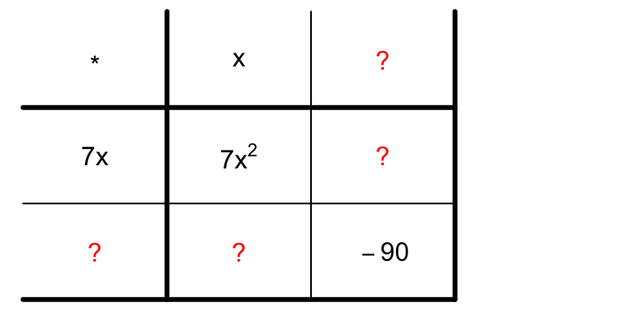

You can get this by guessing and checking. To make a smart guess, find a pair of integers that multiply to get $-90$, and use those…

Eventually, because $(-10)\cdot(9)=-90$, you will guess the following factored form:

$$({7}x-{10})\cdot(x+{9})$$

And you will check it with a box to see that it works.

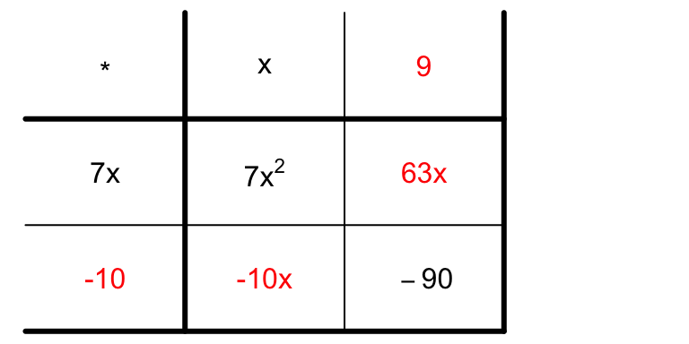

$${7}x^{2}+{63}x-{10}x-{90}$$

Combine like terms.

$${7}x^{2}+{53}x-{90}$$

So it worked! (Because it matches the given standard-form expression.) Thus, in factored form, the expression is:

$$({7}x-{10})\cdot(x+{9})$$

And, the two factors are $({7}x-{10})$ and $(x+{9})$

# Meta-information

extype: mchoice exsolution: 0100000000000000000000000000000000001000 exname: factor_quadratic